# Machine Learning Assignment

## Group 35 Phase 1

Harold Li Guo Choi (s3866530)

Jessica Jiexi Lin (S3852191)

Vanessa Jie En Yew (s3817207)

1. Introduction
   > - Dataset Source
   > - Dataset Details
   > - Dataset Features
   > - Target Feature
2. Goals and Objectives
3. Data Cleaning and Preprocessing
   > - Importing dataset
   > - Checking Feature Type
   > - Removing ID-Like Columns
   > - Checking for Missing Values
   > - Checking unique values for categorical features
   > - Adding new column Total Income
4. Data Exploration and Visualisation
   > - Univariate Plots
   > - Bivariate Plots
   > - Multivariate Plots
5. Summary and Conclusions
6. References

# **Introduction**

## Dataset Source

Singh, S. (2021). Loan Approval Prediction. Kaggle.com. Retrieved 6 April 2021, from https://www.kaggle.com/sonalisingh1411/loan-approval-prediction.

## Dataset Details

The Loan Approval Prediction dataset obtained from Kaggle.com contains the home loan applications from the Dream Housing Finance Company in the United States. The Dream Housing Finance Company offers financing for different kinds of home loans, across all urban, semi-urban and rural areas in the United States.

The dataset contains the details of applicants who has applied for a home loan through their online application form. These details include their Gender, Marital Status, Education Level, Number of Dependents, Income, Loan Amount, Loan Term, Credit History and others.

## Dataset Features

The dataset is a csv file which contains **11 features** with **614 observations**. The 11 variables are as follows:

| Name of Feature | Data Type | Units | Brief Description |
| --- | --- | --- | --- |
| **Gender** | Categorical | Not Applicable | The gender of the applicant: Male / Female |
| **Married** | Categorical | Not Applicable | The marriage status of the applicant: YES / NO |
| **Dependents** | Categorical | Person | The number of dependent applicant has: 0 / 1 / 2 / 3+ |
| **Education** | Ordinal Categorical | Not Applicable | The applicant's education status: Graduate/ Under Graduate |
| **SelfEmployed** | Categorical | Not Applicable | Self Employment status of applicant: YES / NO |
| **ApplicantIncome** | Numerical | USD | Monthly Income of Applicant |
| **CoapplicantIncome** | Numerical | USD | Monthly Income of Coapplicant |
| **LoanAmount** | Numerical | USD | Loan Amount in Thousands |
| **LoanAmountTerm** | Numerical | Months | Term of Loan |
| **CreditHistory** | Binary | Not Applicable | Determine if Applicant's credit history has met with the guidelines : 1 (Met guidelines) / 0 (Did not meet guidelines) |
| **PropertyArea** | Categorical | Not Applicable | Property Area of Applicants: Urban / Semi-Urban / Rural |

## Target Feature

The targetted feature of the loan approval prediction dataset is as follows:

| Name of Feature | Data Type | Units | Brief Description |
| --- | --- | --- | --- |
| **LoanStatus** | Categorical | Not Applicable | The approval status of the loan application: Y (Yes) / N (No) |

# **Goals & Objectives**

The Dream Housing Finance company plans to automate and gain insights about an applicant's loan eligibility based on specific details provided by the applicant. They plan to segment customers who are eligible for their home loan from those who are not using automation.

Loan prediction is a common issue that each bank/loan company faces. They face the challenge of deciding whom they should extend credit to and on what basis that decision is made. Extending credit to an potentially default applicant will be costly. Not extending credit to an applicant would mean losing a potential customer.

Different supervised machine learning models will be fitted to the data, and each one will be evaluated on its accuracy and validity. A machine learning model would be built to help Dream Housing Finance classify if a loan application should be approved based on various variables such as Income, Loan Amount and Credit History.

Through this exercise we hope that our model will help banks/ loan companies understand how to better position themselves to understand and offer loans to applicants through the use of data and machine learning.

# **Data Cleaning & Preprocessing**

### Importing dataset

```python
import warnings
warnings.filterwarnings("ignore")

import numpy as np
import pandas as pd
import io
import matplotlib.pyplot as plt
import seaborn as sns
%matplotlib inline
%config InlineBackend.figure_format = 'retina'
plt.style.use("ggplot")

# so that we can see all the columns
pd.set_option('display.max_columns', None)

from google.colab import files
uploaded = files.upload()

loan_df = pd.read_csv(io.BytesIO(uploaded['Training Dataset.csv']))
print(loan_df)
```

```
Saving Training Dataset.csv to Training Dataset.csv
      Loan_ID  Gender Married Dependents     Education Self_Employed  \
0    LP001002    Male      No          0      Graduate            No
1    LP001003    Male     Yes          1      Graduate            No
2    LP001005    Male     Yes          0      Graduate           Yes
3    LP001006    Male     Yes          0  Not Graduate            No
4    LP001008    Male      No          0      Graduate            No
..        ...     ...     ...        ...           ...           ...
609  LP002978  Female      No          0      Graduate            No
610  LP002979    Male     Yes         3+      Graduate            No
611  LP002983    Male     Yes          1      Graduate            No
612  LP002984    Male     Yes          2      Graduate            No
613  LP002990  Female      No          0      Graduate           Yes

     ApplicantIncome  CoapplicantIncome  LoanAmount  Loan_Amount_Term  \
```

[output cut: 26 more lines]

```python
# 5 randomly selected rows
loan_df.sample(n=5, random_state= 10)
```

|  | Loan_ID | Gender | Married | Dependents | Education | Self_Employed | ApplicantIncome | CoapplicantIncome | LoanAmount | Loan_Amount_Term | Credit_History | Property_Area | Loan_Status |
| --- | --- | --- | --- | --- | --- | --- | --- | --- | --- | --- | --- | --- | --- |
| 285 | LP001924 | Male | No | 0 | Graduate | No | 3158 | 3053.0 | 89.0 | 360.0 | 1.0 | Rural | Y |
| 323 | LP002055 | Female | No | 0 | Graduate | No | 3166 | 2985.0 | 132.0 | 360.0 | NaN | Rural | Y |
| 482 | LP002537 | Male | Yes | 0 | Graduate | No | 2083 | 3150.0 | 128.0 | 360.0 | 1.0 | Semiurban | Y |
| 173 | LP001594 | Male | Yes | 0 | Graduate | No | 5708 | 5625.0 | 187.0 | 360.0 | 1.0 | Semiurban | Y |
| 518 | LP002683 | Male | No | 0 | Graduate | No | 4683 | 1915.0 | 185.0 | 360.0 | 1.0 | Semiurban | N |

### Checking Feature Type

```python
loan_df.dtypes
```

```
Loan_ID               object
Gender                object
Married               object
Dependents            object
Education             object
Self_Employed         object
ApplicantIncome        int64
CoapplicantIncome    float64
LoanAmount           float64
Loan_Amount_Term     float64
Credit_History       float64
Property_Area         object
Loan_Status           object
dtype: object
```

### Removing ID-Like Columns

The Loan_ID column would not be relevant in predictive modelling. By setting it as an ID-like column, the Loan_ID data would not be completely lost, yet it will not be a column anymore.

```python
#setting ID-like columns to be column index
loan_df = loan_df.set_index('Loan_ID')
loan_df.sample(n=5, random_state= 10)
```

| Loan_ID | Gender | Married | Dependents | Education | Self_Employed | ApplicantIncome | CoapplicantIncome | LoanAmount | Loan_Amount_Term | Credit_History | Property_Area | Loan_Status |
| --- | --- | --- | --- | --- | --- | --- | --- | --- | --- | --- | --- | --- |
| LP001924 | Male | No | 0 | Graduate | No | 3158 | 3053.0 | 89.0 | 360.0 | 1.0 | Rural | Y |
| LP002055 | Female | No | 0 | Graduate | No | 3166 | 2985.0 | 132.0 | 360.0 | NaN | Rural | Y |
| LP002537 | Male | Yes | 0 | Graduate | No | 2083 | 3150.0 | 128.0 | 360.0 | 1.0 | Semiurban | Y |
| LP001594 | Male | Yes | 0 | Graduate | No | 5708 | 5625.0 | 187.0 | 360.0 | 1.0 | Semiurban | Y |
| LP002683 | Male | No | 0 | Graduate | No | 4683 | 1915.0 | 185.0 | 360.0 | 1.0 | Semiurban | N |

### Checking for Missing Values

```python
# find the total sum of NA values in each column
loan_df.isna().sum()
```

```
Gender               13
Married               3
Dependents           15
Education             0
Self_Employed        32
ApplicantIncome       0
CoapplicantIncome     0
LoanAmount           22
Loan_Amount_Term     14
Credit_History       50
Property_Area         0
Loan_Status           0
dtype: int64
```

There are a total of 149 missing values in the dataset.

Each detail collected from the loan applicants are deemed as important to determine the status of the loan. As each record are based on individuals, missing value in any of the features would affect the result, it was opted to omit the rows with missing data.

```python
# dropping any rows that have at least one missing value
loan_df = loan_df.dropna()

#Checking to make sure that all rows with missing data are removed.
loan_df.isna().sum()
```

```
Gender               0
Married              0
Dependents           0
Education            0
Self_Employed        0
ApplicantIncome      0
CoapplicantIncome    0
LoanAmount           0
Loan_Amount_Term     0
Credit_History       0
Property_Area        0
Loan_Status          0
dtype: int64
```

```python
#Checking the shape of the dataframe (dataframe as 480 rows and 12 columns)
loan_df.shape
```

```
(480, 12)
```

### Checking unique values for categorical features

Ensuring that each categorical feature has a stated value that is unique and without white spaces or spelling errors.

```python
categorical_cols = loan_df.columns[loan_df.dtypes==object].tolist()
for col in categorical_cols:
  print(col,":", loan_df[col].unique())
```

```
Gender : ['Male' 'Female']
Married : ['Yes' 'No']
Dependents : ['1' '0' '2' '3+']
Education : ['Graduate' 'Not Graduate']
Self_Employed : ['No' 'Yes']
Property_Area : ['Rural' 'Urban' 'Semiurban']
Loan_Status : ['N' 'Y']
```

### Adding new column Total Income

Some of the home loans have coapplicants, therefore, the combined household income should be considered instead.

After aggregating the total household income, the individual applicant and coapplicant income would not be necessary and is therefore removed from the dataset.

```python
total_income = loan_df["ApplicantIncome"] + loan_df["CoapplicantIncome"]
loan_df.insert(5, "TotalHouseholdIncome", total_income, True)
#loan_df.drop(columns=["ApplicantIncome", "CoapplicantIncome"])
del loan_df["ApplicantIncome"]
del loan_df["CoapplicantIncome"]
```

```python
loan_df.describe(include="all").round(2)
```

|  | Gender | Married | Dependents | Education | Self_Employed | TotalHouseholdIncome | LoanAmount | Loan_Amount_Term | Credit_History | Property_Area | Loan_Status |
| --- | --- | --- | --- | --- | --- | --- | --- | --- | --- | --- | --- |
| count | 480 | 480 | 480 | 480 | 480 | 480.00 | 480.00 | 480.00 | 480.00 | 480 | 480 |
| unique | 2 | 2 | 4 | 2 | 2 | NaN | NaN | NaN | NaN | 3 | 2 |
| top | Male | Yes | 0 | Graduate | No | NaN | NaN | NaN | NaN | Semiurban | Y |
| freq | 394 | 311 | 274 | 383 | 414 | NaN | NaN | NaN | NaN | 191 | 332 |
| mean | NaN | NaN | NaN | NaN | NaN | 6945.32 | 144.74 | 342.05 | 0.85 | NaN | NaN |
| std | NaN | NaN | NaN | NaN | NaN | 5969.95 | 80.51 | 65.21 | 0.35 | NaN | NaN |
| min | NaN | NaN | NaN | NaN | NaN | 1442.00 | 9.00 | 36.00 | 0.00 | NaN | NaN |
| 25% | NaN | NaN | NaN | NaN | NaN | 4148.00 | 100.00 | 360.00 | 1.00 | NaN | NaN |
| 50% | NaN | NaN | NaN | NaN | NaN | 5422.50 | 128.00 | 360.00 | 1.00 | NaN | NaN |
| 75% | NaN | NaN | NaN | NaN | NaN | 7672.50 | 170.00 | 360.00 | 1.00 | NaN | NaN |
| max | NaN | NaN | NaN | NaN | NaN | 81000.00 | 600.00 | 480.00 | 1.00 | NaN | NaN |

```python
print(loan_df)
```

```
          Gender Married Dependents     Education Self_Employed  \
Loan_ID
LP001003    Male     Yes          1      Graduate            No
LP001005    Male     Yes          0      Graduate           Yes
LP001006    Male     Yes          0  Not Graduate            No
LP001008    Male      No          0      Graduate            No
LP001011    Male     Yes          2      Graduate           Yes
...          ...     ...        ...           ...           ...
LP002978  Female      No          0      Graduate            No
LP002979    Male     Yes         3+      Graduate            No
LP002983    Male     Yes          1      Graduate            No
LP002984    Male     Yes          2      Graduate            No
LP002990  Female      No          0      Graduate           Yes

          TotalHouseholdIncome  LoanAmount  Loan_Amount_Term  Credit_History  \
Loan_ID
LP001003                6091.0       128.0             360.0             1.0
LP001005                3000.0        66.0             360.0             1.0
LP001006                4941.0       120.0             360.0             1.0
LP001008                6000.0       141.0             360.0             1.0
LP001011                9613.0       267.0             360.0             1.0
...                        ...         ...               ...             ...
LP002978                2900.0        71.0             360.0             1.0
LP002979                4106.0        40.0             180.0             1.0
LP002983                8312.0       253.0             360.0             1.0
LP002984                7583.0       187.0             360.0             1.0
LP002990                4583.0       133.0             360.0             0.0

         Property_Area Loan_Status
Loan_ID
LP001003         Rural           N
LP001005         Urban           Y
LP001006         Urban           Y
LP001008         Urban           Y
LP001011         Urban           Y
...                ...         ...
LP002978         Rural           Y
LP002979         Rural           Y
LP002983         Urban           Y
LP002984         Urban           Y
LP002990     Semiurban           N

[480 rows x 11 columns]
```

```python
# phase 2
loan_df.head(5)
```

| Loan_ID | Gender | Married | Dependents | Education | Self_Employed | TotalHouseholdIncome | LoanAmount | Loan_Amount_Term | Credit_History | Property_Area | Loan_Status |
| --- | --- | --- | --- | --- | --- | --- | --- | --- | --- | --- | --- |
| LP001003 | Male | Yes | 1 | Graduate | No | 6091.0 | 128.0 | 360.0 | 1.0 | Rural | N |
| LP001005 | Male | Yes | 0 | Graduate | Yes | 3000.0 | 66.0 | 360.0 | 1.0 | Urban | Y |
| LP001006 | Male | Yes | 0 | Not Graduate | No | 4941.0 | 120.0 | 360.0 | 1.0 | Urban | Y |
| LP001008 | Male | No | 0 | Graduate | No | 6000.0 | 141.0 | 360.0 | 1.0 | Urban | Y |
| LP001011 | Male | Yes | 2 | Graduate | Yes | 9613.0 | 267.0 | 360.0 | 1.0 | Urban | Y |

```python
loan_df.to_csv("loan_clean.csv", index= True)
```

# **Data Exploration & Visualisation**

We have use three types of plots - univariate, bivariate and multivariate, to visualize and draw insights to the dataset and the nature of the applicants and details given to Dream Housing Finance Company.

## Univariate Plots

In this section, we will perform a univariate analysis to examine each variable individually.

### 1. Target Variable

We will first examine the target variable, Loan Status. The loan status of the applicant is either approved or rejected, with 'Y' for approved and 'N' for rejected.

```python
print(loan_df['Loan_Status'].value_counts())
print(loan_df['Loan_Status'].value_counts(normalize=True)*100)
```

```
Y    332
N    148
Name: Loan_Status, dtype: int64
Y    69.166667
N    30.833333
Name: Loan_Status, dtype: float64
```

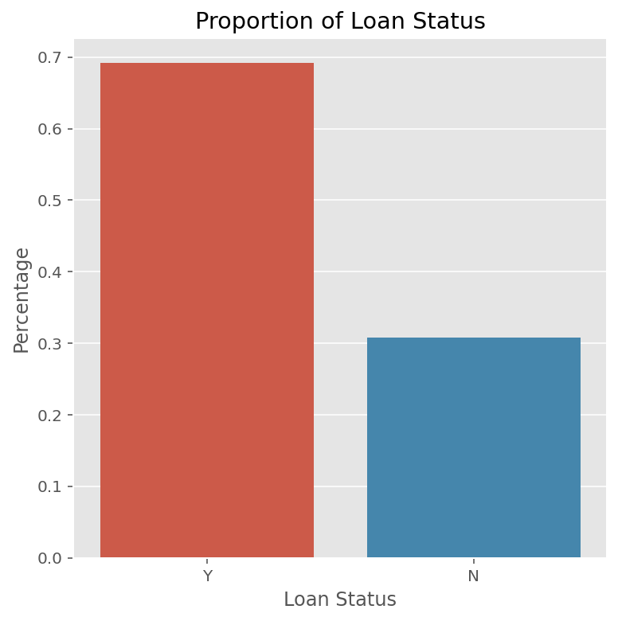

```python
temp = loan_df["Loan_Status"].value_counts(normalize=True)
df = pd.DataFrame({'Loan Status': temp.index,
                   'Percentage': temp.values
                  })
plt.figure(figsize = (6,6))
plt.title('Proportion of Loan Status')
sns.set_color_codes("pastel")
sns.barplot(x = 'Loan Status', y="Percentage", data=df)
plt.show()
```

Among 480 loan application, 332 *(69.17%)* are approved while 148 *(30.83%)* are rejected.

### 2. Gender Variable

```python
print(loan_df['Gender'].value_counts())
print(loan_df['Gender'].value_counts(normalize=True)*100)
```

```
Male      394
Female     86
Name: Gender, dtype: int64
Male      82.083333
Female    17.916667
Name: Gender, dtype: float64
```

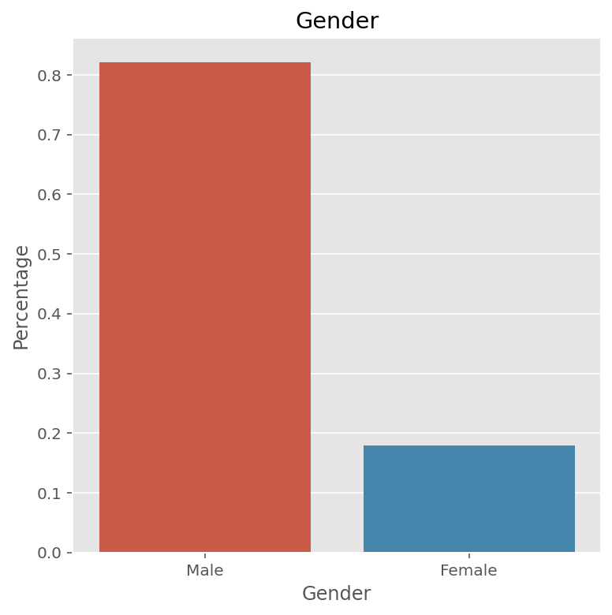

```python
temp = loan_df["Gender"].value_counts(normalize=True)
df = pd.DataFrame({'Gender': temp.index,
                   'Percentage': temp.values})
plt.figure(figsize = (6,6))
plt.title('Gender')
sns.set_color_codes("pastel")
sns.barplot(x = 'Gender', y='Percentage', data=df)
plt.show()
```

### 3. Education Background

```python
print(loan_df['Education'].value_counts())
print(loan_df['Education'].value_counts(normalize=True)*100)
```

```
Graduate        383
Not Graduate     97
Name: Education, dtype: int64
Graduate        79.791667
Not Graduate    20.208333
Name: Education, dtype: float64
```

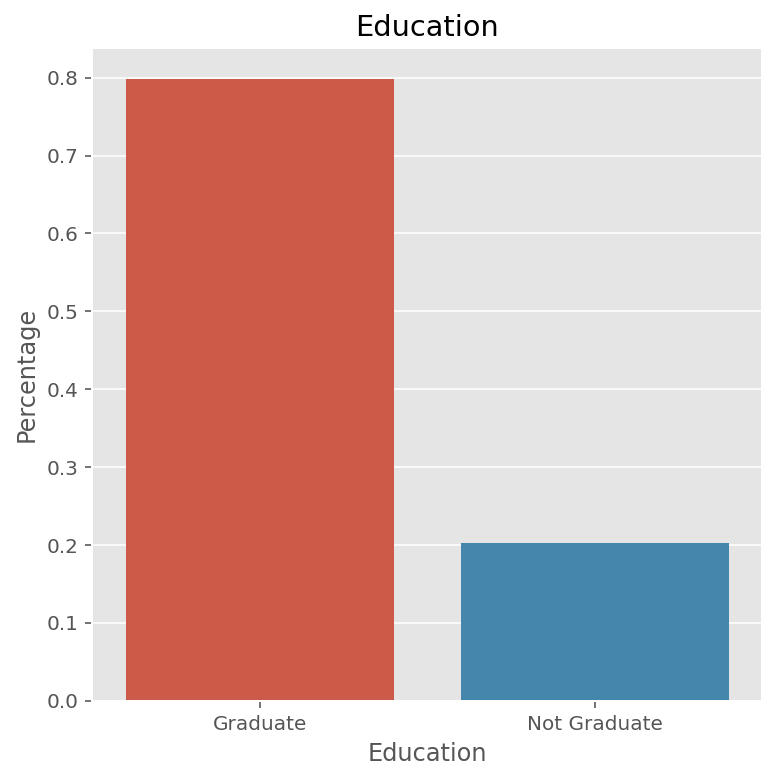

```python
temp = loan_df["Education"].value_counts(normalize=True)
df = pd.DataFrame({'Education': temp.index,
                   'Percentage': temp.values})
plt.figure(figsize = (6,6))
plt.title('Education')
sns.set_color_codes("pastel")
sns.barplot(x = 'Education', y="Percentage", data=df)
plt.show()
```

### 4. Credit History

The credit history of the applicant could have either met the guidelines or failed to meet the guidelines, with '1' for met and '0' for failed.

```python
print(loan_df["Credit_History"].value_counts())
print(loan_df["Credit_History"].value_counts(normalize=True)*100)
```

```
1.0    410
0.0     70
Name: Credit_History, dtype: int64
1.0    85.416667
0.0    14.583333
Name: Credit_History, dtype: float64
```

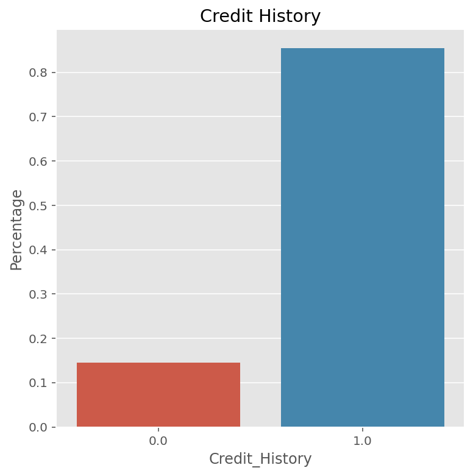

```python
temp = loan_df["Credit_History"].value_counts(normalize=True)
df = pd.DataFrame({'Credit_History': temp.index,
                   'Percentage': temp.values})
plt.figure(figsize = (6,6))
plt.title('Credit History')
sns.set_color_codes("pastel")
sns.barplot(x = 'Credit_History', y="Percentage", data=df)
plt.show()
```

From the bar graph above, 410 *(85.42%)* applicants have good credit history while 70 *(14.58%)* have do not.

### 5. Distribution of Loan Term

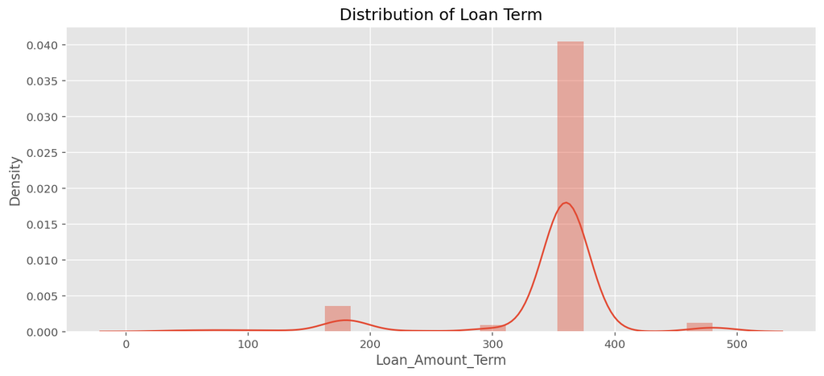

```python
plt.figure(figsize=(12,5))
plt.title("Distribution of Loan Term")
ax = sns.distplot(loan_df["Loan_Amount_Term"])
```

### 6. Distribution of Total Household Income

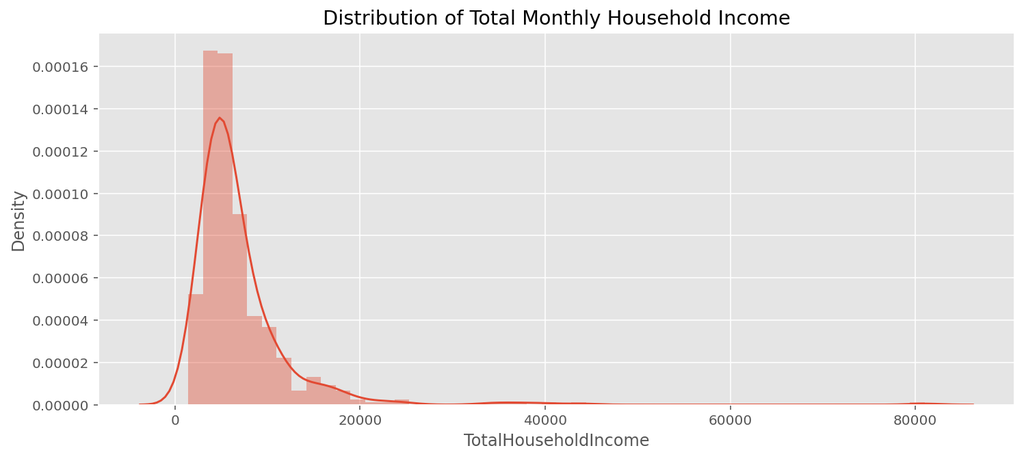

```python
plt.figure(figsize=(12,5))
plt.title("Distribution of Total Monthly Household Income")
ax = sns.distplot(loan_df["TotalHouseholdIncome"])
```

The distribution of the total household income is right skewed with the bulk of the data on the left where majority of the total household income is less than 10,000 USD per month.

### 7. Distribution of Loan Amount

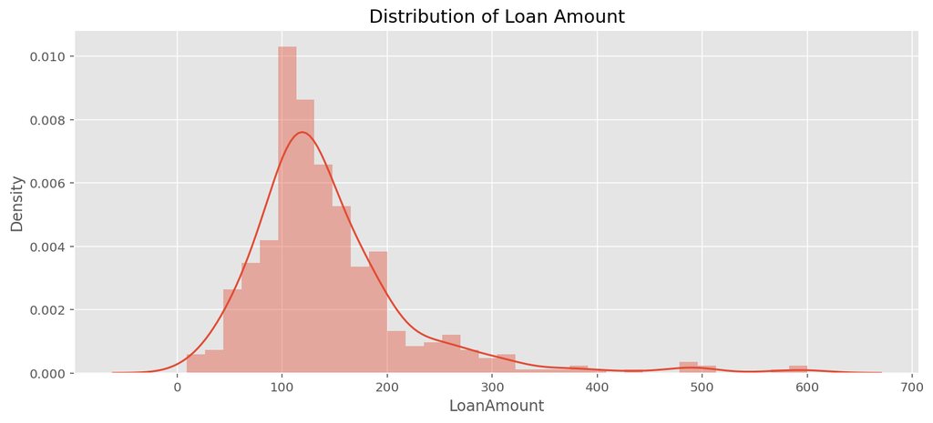

```python
plt.figure(figsize=(12,5))
plt.title("Distribution of Loan Amount")
ax = sns.distplot(loan_df["LoanAmount"])
```

Similar to the total household income, the loan amount is right skewed although there are less outliers in this instance. We see that majority of the applicants are requesting for loan amounting from 50k to 250k USD.

## Bivariate Plots

### 1. Relationship between Loan Status and Credit History

```python
print(pd.crosstab(loan_df['Loan_Status'], loan_df['Credit_History']))
```

```
Credit_History  0.0  1.0
Loan_Status
N                63   85
Y                 7  325
```

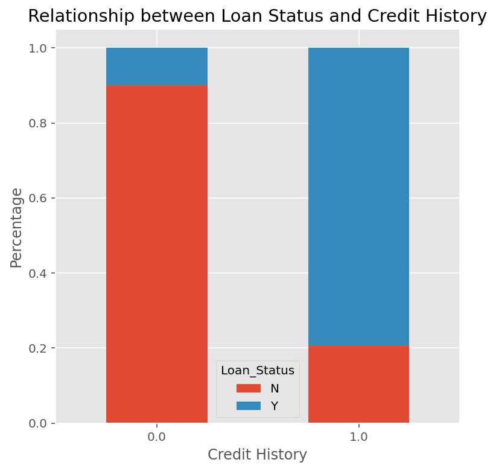

```python
credit_history = pd.crosstab(loan_df['Credit_History'], loan_df['Loan_Status'])
credit_history.div(credit_history.sum(1).astype(float),axis=0).plot(kind="bar",stacked=True,figsize = (6,6))
plt.xlabel("Credit History")
plt.ylabel("Percentage")
plt.xticks(rotation=0)
plt.title('Relationship between Loan Status and Credit History')
plt.show()
```

Among those who met the credit history guidelines, 325 *(79.3%)* applicants had their loan granted approval and only 85 *(20.7%)* of them were not granted the loan approval.

Among those who did not meet the credit history guidelines only 7 *(10%)* of them were granted loan approval while 63 *(90%)* applicants were not.

Comparing the blue colored columns, if an applicant fulfills the credit history guidelines, the likelihood of the approval of their application would be higher.

### 2. Relationship between Loan Status and Education

```python
print(pd.crosstab(loan_df["Loan_Status"],loan_df["Education"]))
```

```
Education    Graduate  Not Graduate
Loan_Status
N                 112            36
Y                 271            61
```

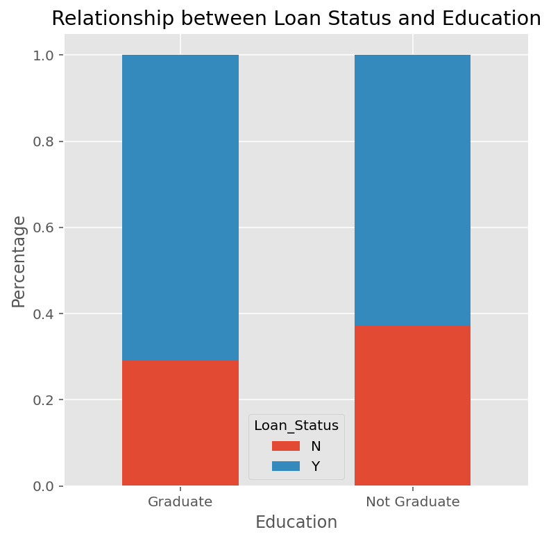

```python
education = pd.crosstab(loan_df["Education"],loan_df["Loan_Status"])
education.div(education.sum(1).astype(float),axis=0).plot(kind="bar",stacked=True,figsize=(6,6))
plt.xlabel("Education")
plt.ylabel("Percentage")
plt.xticks(rotation=0)
plt.title('Relationship between Loan Status and Education')
plt.show()
```

From the graph, 112 *(29.2%)* applicants who are graduates have their applications not approved, while 271 *(70.8%)* of them have their loan application approved.

On the other hand, 36 *(37.1%)* applicants who are not graduates do not have their loan approved, while 61 *(62.9%)* of them have their loans approved.

Applicants who are graduates have a higher chance of getting their home loans approved as opposed to the applicants who are not, however that difference between them are not by much.

### 3. Relationship between Loan Status and Property Area of Applicant

```python
print(pd.crosstab(loan_df['Loan_Status'], loan_df['Property_Area']))
```

```
Property_Area  Rural  Semiurban  Urban
Loan_Status
N                 54         42     52
Y                 85        149     98
```

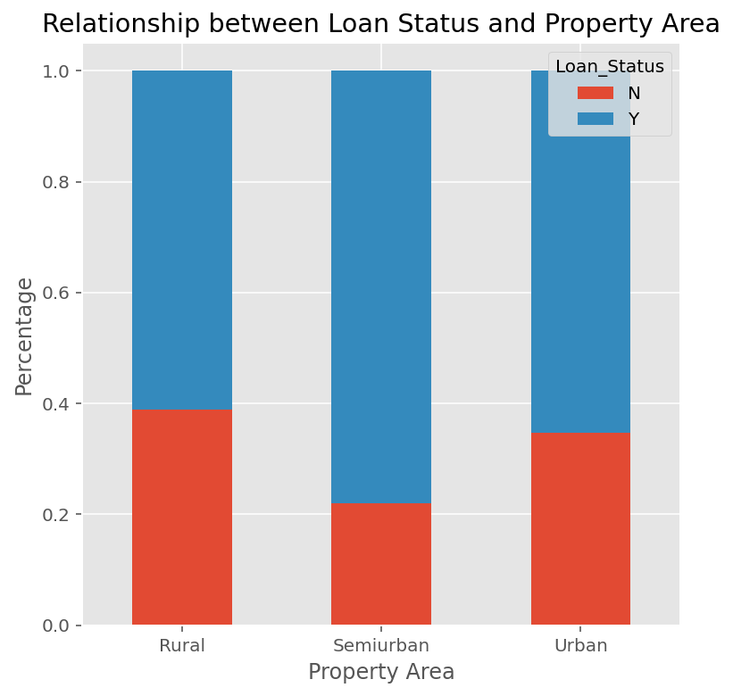

```python
property_area = pd.crosstab(loan_df['Property_Area'], loan_df['Loan_Status'])
property_area.div(property_area.sum(1).astype(float),axis=0).plot(kind="bar",stacked=True,figsize=(6,6))
plt.xlabel("Property Area")
plt.ylabel("Percentage")
plt.xticks(rotation=0)
plt.title('Relationship between Loan Status and Property Area')
plt.show()
```

Zooming in on the first bar column, 54 *(38.8%)* applicants from the Rural Area did not have their application granted while 85 *(61.2%)* of them were granted.

On the other hand, 42 *(22%)* applicants from the Semi Urbanised Area had their application rejected while 149 *(78%)* were granted.

Lastly, 52 *(34.7%)* applicants from the Urban Area had their application rejected while 98 *(65.3%)* were granted.

Based on the cross tabulation numbers, the applicants from Semi-urban Area are most likely to be granted loans, followed by Urbanised Area then Rural Area.

### 4. Relationship between Loan Status and Gender

```python
pd.crosstab( loan_df['Loan_Status'], loan_df['Gender'])
```

| Gender Loan_Status | Female | Male |
| --- | --- | --- |
| N | 32 | 116 |
| Y | 54 | 278 |

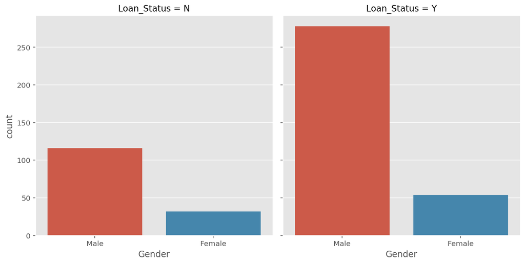

```python
sns.catplot(x='Gender', col='Loan_Status',data=loan_df, kind='count', ci=False)
plt.show()
```

From the graph, amongst the people who have their loan application rejected, 32 *(21.6%)* of them are females and 116 *(78.4%)* of them are males.

On the other hand, amongst the people who have their loan application accepted, 54 *(16.3%)* of them are females and 278 *(83.7%)* of them are males.

Therefore, it seems that gender on its own does not contribute much to the loan application status.

## Multivariate Plots

### 1. Relationship between Loan Status, Loan Amount and Property Area

```python
table = pd.pivot_table(loan_df,  index='Loan_Status', columns='Property_Area', values='LoanAmount').round(2)
table
```

| Property_Area Loan_Status | Rural | Semiurban | Urban |
| --- | --- | --- | --- |
| N | 167.04 | 157.52 | 135.85 |
| Y | 148.40 | 142.83 | 131.41 |

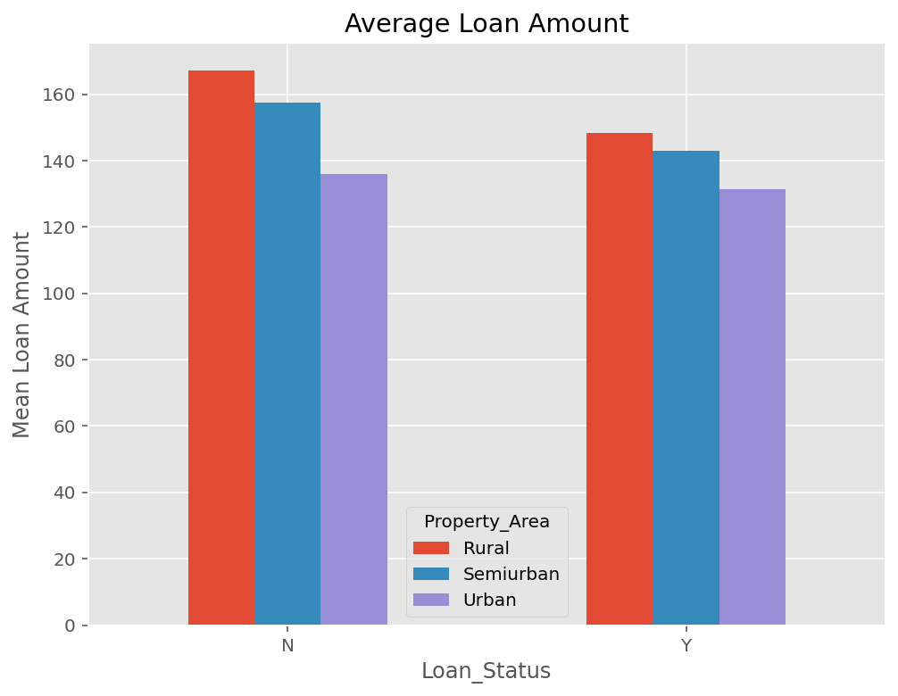

```python
table.plot(kind='bar', figsize = (8,6))
plt.ylabel('Mean Loan Amount')
plt.xticks(rotation=0)
plt.title('Average Loan Amount')
```

From the graph, amongst the loans that are not approved, the rural area has the highest average loan (USD 167.04k) , followed by the semi-urbanised area (USD 157.52k) and then the urban area (USD 135.85k).

This result is no different from those amongst the approved loans, with the rural having the highest loan average (148.40k), followed by the semi-urbanised (142.83k) and then urbanised (131.41k).

From the result, we can deem that the mean loan amount requested by the applicant staying in rural areas are the highest.

Overall, across all property area, it seems that loans that are approved have a lower mean loan amount.

### 2. Relationship between Loan Status, Gender and Total Household Income

```python
table1 = pd.pivot_table(loan_df,  index='Loan_Status', columns='Gender', values='TotalHouseholdIncome').round(2)
table1
```

| Gender Loan_Status | Female | Male |
| --- | --- | --- |
| N | 4942.97 | 8209.56 |
| Y | 6109.72 | 6810.60 |

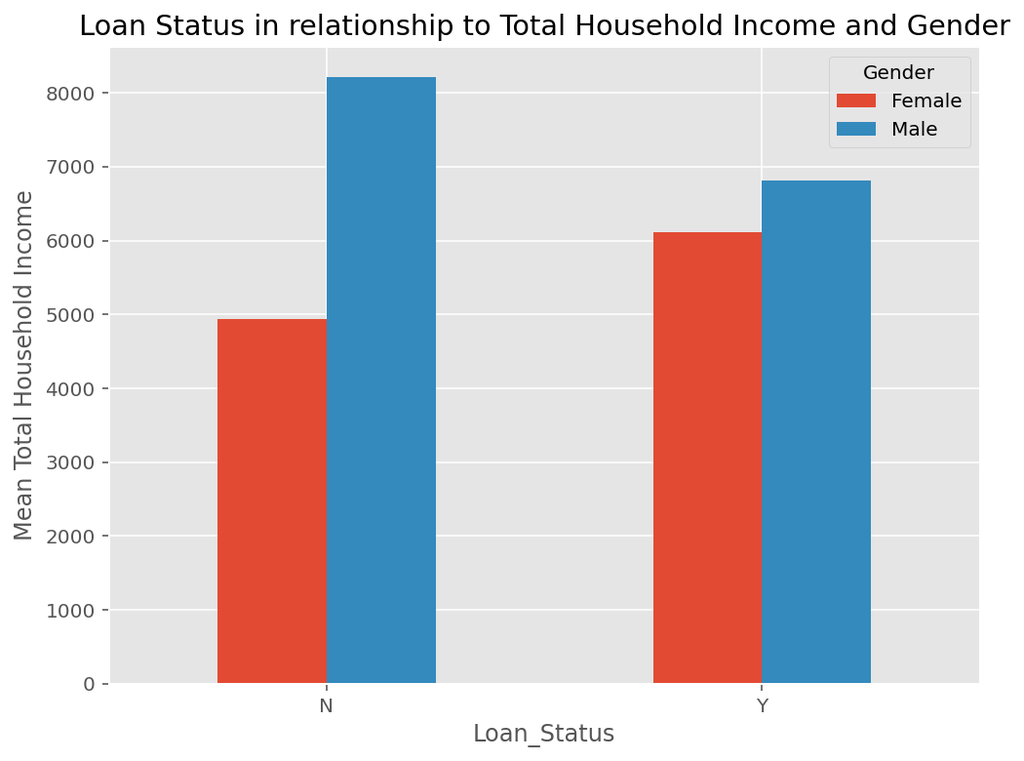

```python
table1.plot(kind='bar', figsize = (8,6))
plt.ylabel('Mean Total Household Income')
plt.xticks(rotation=0)
plt.title('Loan Status in relationship to Total Household Income and Gender')
```

From the graph, amongst the loans that were not approved, males had an average household income of USD 8209.56 while females only had an average household income of USD 4942.97.

On the other hand, amongst the loans that were approved, males had an average household income of USD 6810.60 while females only had an average household income of USD 6109.72.

From the result, we can deduce that male applicants tend to have a higher total household income.

The female applicants who had their loans approved had a higher average household income as compared to the females who did not have their loan approved.

On the other hand, the male applicants who had their loans approved had a lower average household income as compared to the males who do not have their loans approved. This might be due to outliers or other various reasons which require further investigation.

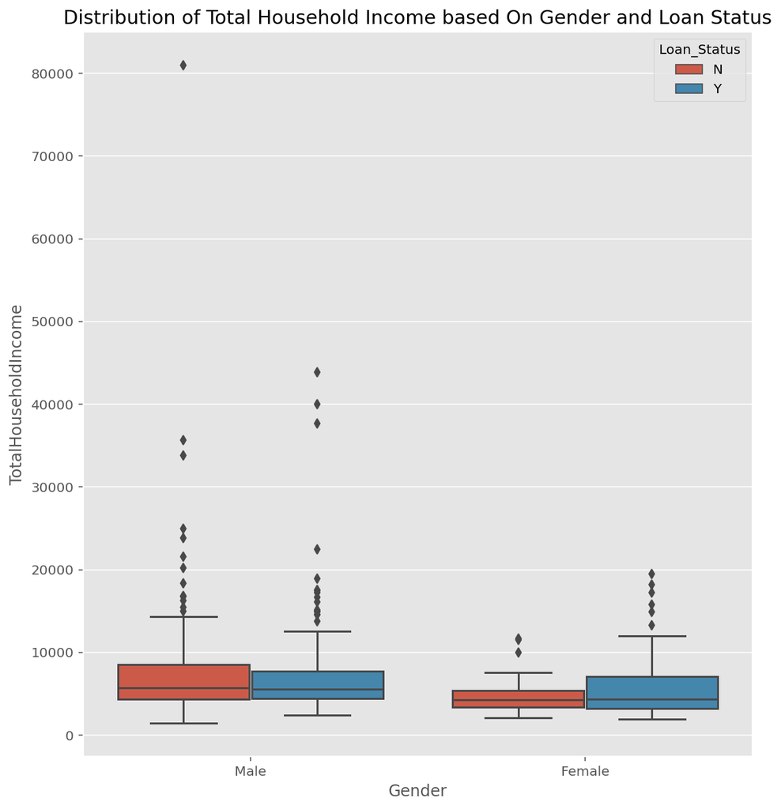

```python
plt.figure(figsize = (9,10))
plt.title('Distribution of Total Household Income based On Gender and Loan Status')
sns.set_color_codes("pastel")
sns.boxplot(x = loan_df['Gender'], y=loan_df["TotalHouseholdIncome"], hue=loan_df["Loan_Status"], data=df)
plt.show()
```

From the graph, we can see that the reason for wide gap between the male applicants on their average total household income was due to an outlier (a male applicant whose loan application was rejected has a total household income of 80,000 USD).

### 4. Correlation Heatmap

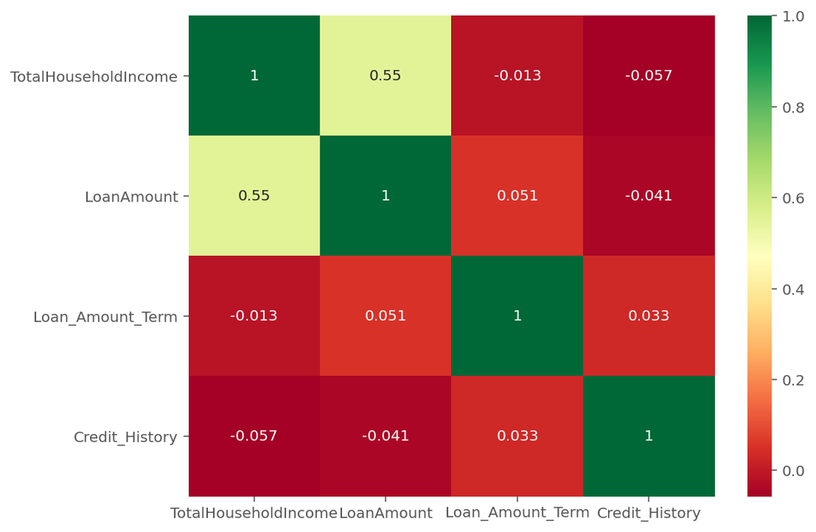

```python
plt.figure(figsize = (8,6))
sns.heatmap(loan_df.corr(), annot=True,cmap ='RdYlGn')
```

The two features that are correlated are the loan amount and the total household income. However, even as they are correlated, they are only moderately correlated and should not cause multicollinearity issues.

As the two features are important features, we should still keep them in the model. The correlation between the other features are negligible.

### 5. Scatter Plot of Loan Amount and Total Household Income

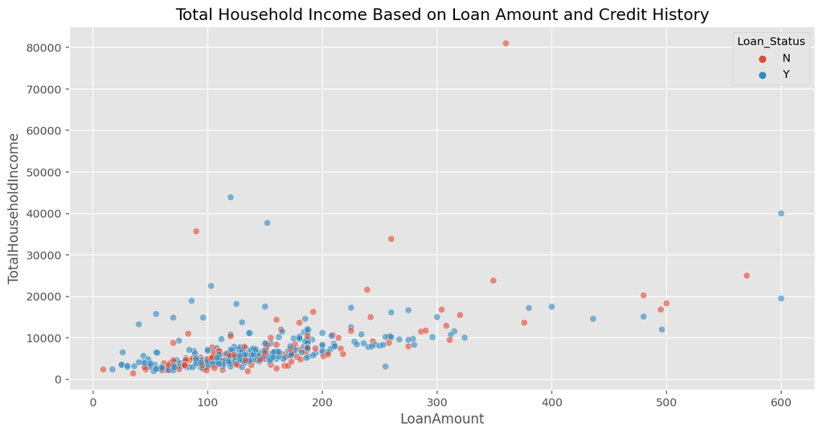

```python
plt.figure(figsize = (12,6))
plt.title('Total Household Income Based on Loan Amount and Credit History')
sns.scatterplot(x=loan_df['LoanAmount'], y=loan_df['TotalHouseholdIncome'], hue=loan_df['Loan_Status'], alpha=0.6)
```

```python
loan_df
```

| Loan_ID | Gender | Married | Dependents | Education | Self_Employed | TotalHouseholdIncome | LoanAmount | Loan_Amount_Term | Credit_History | Property_Area | Loan_Status |
| --- | --- | --- | --- | --- | --- | --- | --- | --- | --- | --- | --- |
| LP001003 | Male | Yes | 1 | Graduate | No | 6091.0 | 128.0 | 360.0 | 1.0 | Rural | N |
| LP001005 | Male | Yes | 0 | Graduate | Yes | 3000.0 | 66.0 | 360.0 | 1.0 | Urban | Y |
| LP001006 | Male | Yes | 0 | Not Graduate | No | 4941.0 | 120.0 | 360.0 | 1.0 | Urban | Y |
| LP001008 | Male | No | 0 | Graduate | No | 6000.0 | 141.0 | 360.0 | 1.0 | Urban | Y |
| LP001011 | Male | Yes | 2 | Graduate | Yes | 9613.0 | 267.0 | 360.0 | 1.0 | Urban | Y |
| ... | ... | ... | ... | ... | ... | ... | ... | ... | ... | ... | ... |
| LP002978 | Female | No | 0 | Graduate | No | 2900.0 | 71.0 | 360.0 | 1.0 | Rural | Y |
| LP002979 | Male | Yes | 3+ | Graduate | No | 4106.0 | 40.0 | 180.0 | 1.0 | Rural | Y |
| LP002983 | Male | Yes | 1 | Graduate | No | 8312.0 | 253.0 | 360.0 | 1.0 | Urban | Y |
| LP002984 | Male | Yes | 2 | Graduate | No | 7583.0 | 187.0 | 360.0 | 1.0 | Urban | Y |
| LP002990 | Female | No | 0 | Graduate | Yes | 4583.0 | 133.0 | 360.0 | 0.0 | Semiurban | N |

480 rows × 11 columns

From the scatterplot we can see a large majority of applicant have applied for loan amounting to less than 200k USD and their total household income are usually less than 10,000 USD. However, there is a mixed variety of loan status within, implying that there are other factors contributing to the loan status.

# Summary & Conclusions

The Dream Housing Finance company is looking to automate and gain insights on their applicant's loan eligibility based on specific details provided by the applicants.

This project ultimately aims to build different supervised machine learning models to help Dream Housing Finance classify the loan status of their applicants. Each model will be evaluated on its accuracy and validity.

At phase 1 of the project, the loan approval data set is examined and pre-processed. This include ensuring that each features are of the right type, removing the ID-Like column, checking for missing values and checking the unique values for all categorical features.

A new column `Total Household Income` is added in the dataset by aggregating both "Applicant Income" and "Coapplicant Income" as the total income of the applicants are usually taken into consideration since they would most likely co-pay the home loans. As such, both `Applicant Income` and `Coapplicant Income` are removed from the dataset.

In addition, visualisations have been used to examine on how various variables might affect the loan status.

In addition, the gender of the applicants do not contribute much to the outcome of the loan status although it is found that the male applicants tend to generally have a higher income. The female applicants who have their loans approved have a higher average household income as compared to the females who do not have their loan approved.

Looking at property of the applicants, the applicants from the Semi-Urbanised Area are most likely to be granted loans, followed by the Urbanised Area and then the Rural Area. The average loan amount requested by the applicant staying in Rural Areas are the highest. Overall, across all property areas, loans that are approved have a lower average loan amount.

The data visualisation and exploration stage has given insight into what features may potentially be significant to the predication of their loan application status. This will aid in the selection of features in the future steps for creating the different machine learning models. The next phase for this project will involve exploring different machine learning algorithms with this processed dataset, and evaluating the accuracy and validity of each.

# References

Singh, S. (2021). Loan Approval Prediction. Kaggle.com. Retrieved 6 April 2021, from https://www.kaggle.com/sonalisingh1411/loan-approval-prediction.